# Comparative Genomics Southern Flounder

#### Filter 3: missing data (locus/indv) I

Distribution of missing data per locus:

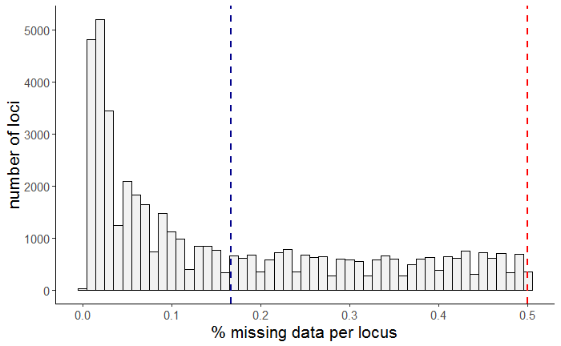

```r
loc_stats_F2 <- read.loc.stats(dir = "data/VCF/", vcf = "FamB.F2")
# plot distribution missing data
ggplot(loc_stats_F2, aes(x = MISS_FamB.F2)) +
  geom_histogram(binwidth = 0.01, color = "black", fill = "grey95") +
  geom_vline(aes(xintercept = mean(MISS_FamB.F2, na.rm = TRUE)),
                 color = "darkblue", linetype = "dashed", size = 1) +
    geom_vline(aes(xintercept = 0.5),
                 color = "red", linetype = "dashed", size = 1) +
  labs(x = "% missing data per locus", y = "number of loci") +
  theme_standard
```

```r
count(loc_stats_F2, MISS_FamB.F2 < 0.2)
```

| MISS_FamB.F2 < 0.2 | n |
| --- | --- |
| FALSE | 17174 |
| TRUE | 29853 |

Filter loci with genotype call rate < 0.8.

```
vcftools --vcf FamB.F2.recode.vcf --out FamB.F3a --max-missing 0.8 --recode --recode-INFO-all
vcftools --vcf FamB.F3a.recode.vcf --out FamB.F3a --missing-indv
```

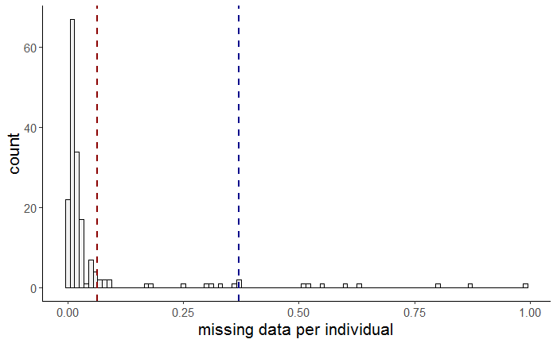

```r
imiss_F3 <- read.table("data/VCF/FamB.F3a.imiss",
                       header = TRUE, stringsAsFactors = FALSE)
ggplot(imiss_F3, aes(x = F_MISS)) +
  geom_histogram(binwidth = .01, color = "black", fill = "grey95") +
  geom_vline(aes(xintercept = mean(F_MISS, na.rm = TRUE)),
                 color = "darkred", linetype = "dashed", size = 1) +
  geom_vline(aes(xintercept = quantile(F_MISS, .95)),
                 color = "darkblue", linetype = "dashed", size = 1) +
  labs(x = "missing data per individual") +
  theme_standard
```

Remove individuals with more than 80% missing data

```
mawk -v x=0.8 '$5 > x' FamB.F3a.imiss | cut -f1 > lowDP.indv
vcftools --vcf FamB.F3a.recode.vcf --remove lowDP.indv --out FamB.F3b --recode --recode-INFO-all
```

Remaining loci: 30.217 loci and 173 individuals.

#### Filter 4: minor allele frequency, mean minimum depth I

Remove loci with minor allele frequency < 0.01 and mean minimum depth (across all individuals) < 15

```
vcftools --vcf FamB.F3b.recode.vcf --out FamB.F4a --min-meanDP 15 --recode --recode-INFO-all
```

Remaining loci: 26,419.

```
vcftools --vcf FamB.F4a.recode.vcf --out FamB.F4b --maf 0.01 --recode --recode-INFO-all
```

Remaining loci: 25,523

```
vcftools --vcf FamB.F4b.recode.vcf --out FamB.F4 --missing-indv
vcftools --vcf FamB.F4b.recode.vcf --out FamB.F4 --missing-site
vcftools --vcf FamB.F4b.recode.vcf --out FamB.F4 --depth
vcftools --vcf FamB.F4b.recode.vcf --out FamB.F4 --site-mean-depth
vcftools --vcf FamB.F4b.recode.vcf --out FamB.F4 --het
```

Assess individual quality by comparing levels of missing data and read depth.

```r
ind_stats_F4 <- read.ind.stats(dir = "data/VCF", vcf = "FamB.F4") %>%
  separate(INDV, into = c("SP", "LIB", "SAMPLE_ID"), sep = "_", remove = FALSE)
```

Mean read depth per individual across all SNP sites, the mean mean depth across all SNP sites is 85.6774976, the 5th % quantile is 12.4986:

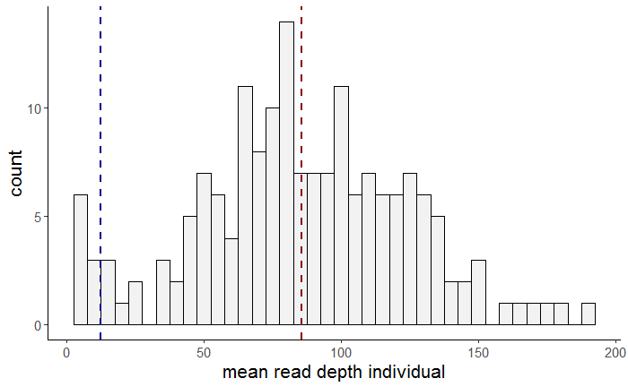

Frequency of missing data per individual across all SNP sites:

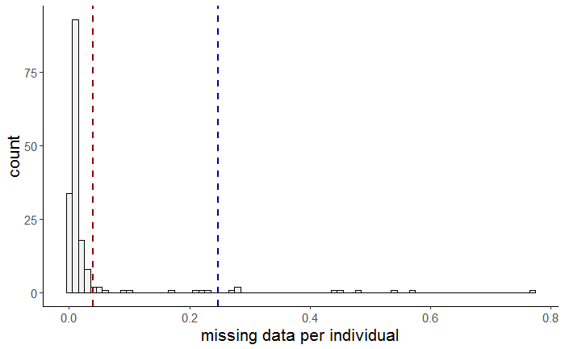

```r
ggplot(ind_stats_F4, aes(x = MISS_FamB.F4)) +
  geom_histogram(binwidth = .01, color = "black", fill = "grey95") +
  geom_vline(aes(xintercept = mean(MISS_FamB.F4, na.rm = TRUE)),
                 color = "darkred", linetype = "dashed", size = 1) +
  geom_vline(aes(xintercept = quantile(MISS_FamB.F4, .95)),
                 color = "darkblue", linetype = "dashed", size = 1) +
  labs(x = "missing data per individual") +
  theme_standard
```

Heterozygosity per individual across all SNP sites; the mean values for Fis is -0.2228253, the 95th % quantile is -0.119754 and the 5th % quantile is -0.773586:

```
There were 16 warnings (use warnings() to see them)
```

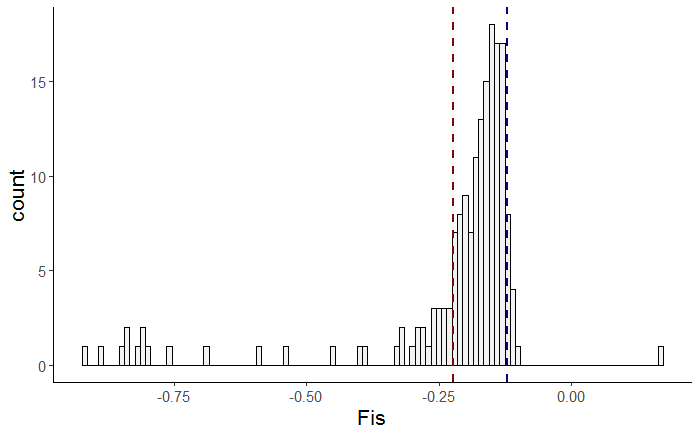

```r
ggplot(ind_stats_F4, aes(x = Fis_FamB.F4)) +
  geom_histogram(binwidth = .01, color = "black", fill = "grey95") +
  geom_vline(aes(xintercept = mean(Fis_FamB.F4, na.rm = TRUE)),
                 color = "darkred", linetype = "dashed", size = 1) +
  geom_vline(aes(xintercept = quantile(Fis_FamB.F4, .95)),
                 color = "darkblue", linetype = "dashed", size = 1) +
  labs(x = "Fis") +
  theme_standard
```

#### Filter 5: missing data (locus/indv) II

Remove loci with genotype call rate < 0.9

```
vcftools --vcf FamB.F4b.recode.vcf --out FamB.F5a --max-missing 0.9  --recode --recode-INFO-all
vcftools --vcf FamB.F5a.recode.vcf --out FamB.F5a --missing-indv
```

Remaining loci: 23,147

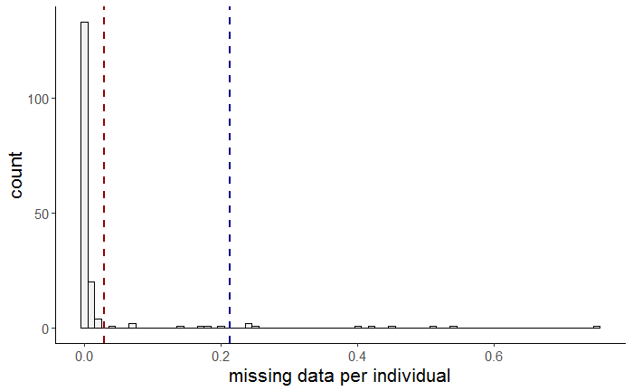

Remove individuals with >50% missing data.

```
mawk -v x=0.5 '$5 > x' FamB.F5a.imiss | cut -f1 > lowDP.indv
vcftools --vcf FamB.F5a.recode.vcf --remove lowDP.indv --recode --recode-INFO-all --out FamB.F5b
```

Data set contains 170 individuals and 23,147 SNPs

#### Filter 6: minor allele frequency, mean minimum depth II

Filter loci with mean minimum depth (across all individuals) < 20

```
vcftools --vcf FamB.F5b.recode.vcf --out FamB.F6a --min-meanDP 20 --recode --recode-INFO-all
```

Filter loci with minor allele frequency < 0.03.

```
vcftools --vcf FamB.F6a.recode.vcf --out FamB.F6b --maf 0.03 --recode --recode-INFO-all
```

Remaining loci: 20,919

```
vcftools --vcf FamB.F6b.recode.vcf --out FamB.F6 --depth
vcftools --vcf FamB.F6b.recode.vcf --out FamB.F6 --site-mean-depth
vcftools --vcf FamB.F6b.recode.vcf --out FamB.F6 --het
vcftools --vcf FamB.F6b.recode.vcf --out FamB.F6 --missing-indv
vcftools --vcf FamB.F6b.recode.vcf --out FamB.F6 --missing-site
```

Assess individual quality by comparing levels of missing data and read depth.

```r
ind_stats_F6 <- read.ind.stats(dir = "data/VCF", vcf = "FamB.F6") %>%
  separate(INDV, into = c("SP", "LIB", "SAMPLE_ID"), sep = "_", remove = FALSE)
```

Mean read depth per individual across all SNP sites, the mean mean depth across all SNP sites is 98.2196508, the 5th % quantile is 19.1331:

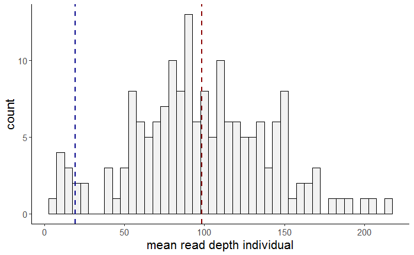

Frequency of missing data per individual across all SNP sites; the mean mean depth across all individuals is 0.0154928, the 95th % quantile is 0.1177946:

```
There were 32 warnings (use warnings() to see them)
```

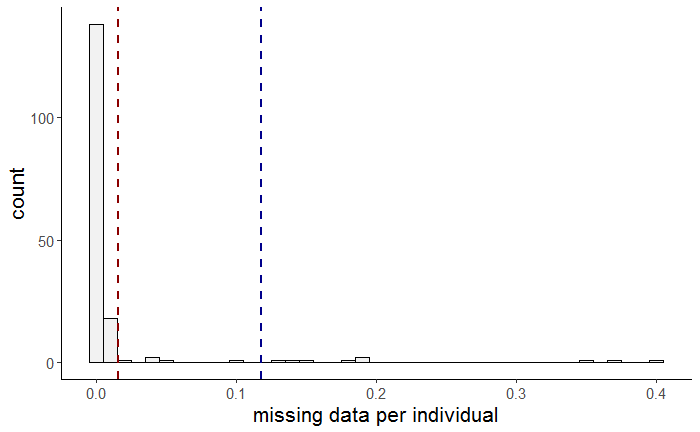

```r
ggplot(ind_stats_F6, aes(x = MISS_FamB.F6)) +
  geom_histogram(binwidth = .01, color = "black", fill = "grey95") +
  geom_vline(aes(xintercept = mean(MISS_FamB.F6, na.rm = TRUE)),
                 color = "darkred", linetype = "dashed", size = 1) +
  geom_vline(aes(xintercept = quantile(MISS_FamB.F6, .95)),
                 color = "darkblue", linetype = "dashed", size = 1) +
  labs(x = "missing data per individual") +
  theme_standard
```

Heterozygosity per individual across all SNP sites; the mean values for Fis is -0.2218719, the 95th % quantile is -0.1313135 and the 5th % quantile is -0.598912:

```
There were 16 warnings (use warnings() to see them)
```

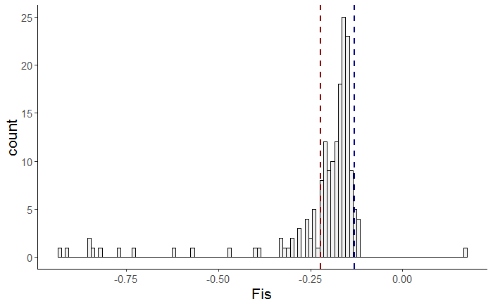

```r
ggplot(ind_stats_F6, aes(x = Fis_FamB.F6)) +
  geom_histogram(binwidth = .01, color = "black", fill = "grey95") +
  geom_vline(aes(xintercept = mean(Fis_FamB.F6, na.rm = TRUE)),
                 color = "darkred", linetype = "dashed", size = 1) +
  geom_vline(aes(xintercept = quantile(Fis_FamB.F6, .95)),
                 color = "darkblue", linetype = "dashed", size = 1) +
  labs(x = "Fis") +
  theme_standard
```

#### Filter 7: missing data (locus/indv) III

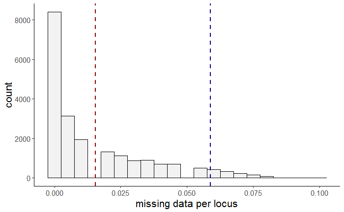

```r
lmiss_F6 <- read.table("data/VCF/FamB.F6.lmiss", header = TRUE, stringsAsFactors = FALSE)
ggplot(lmiss_F6, aes(x = F_MISS)) +
  geom_histogram(binwidth = .005, color = "black", fill = "grey95") +
  geom_vline(aes(xintercept = mean(F_MISS, na.rm = TRUE)),
                 color = "darkred", linetype = "dashed", size = 1) +
  geom_vline(aes(xintercept = quantile(F_MISS, .95)),
                 color = "darkblue", linetype = "dashed", size = 1) +
  labs(x = "missing data per locus") +
  theme_standard
```

```
vcftools --vcf FamB.F6b.recode.vcf --out FamB.F7a --max-missing 0.95 --recode --recode-INFO-all
vcftools --vcf FamB.F7a.recode.vcf --out FamB.F7a --missing-indv
```

Remaining loci: 19,132 (of 20,919)

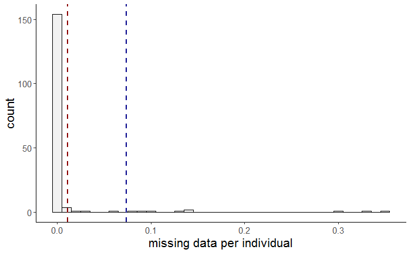

```r
imiss_F7 <- read.table("data/VCF/FamB.F7a.imiss",
                       header = TRUE, stringsAsFactors = FALSE)
ggplot(imiss_F7, aes(x = F_MISS)) +
  geom_histogram(binwidth = .01, color = "black", fill = "grey95") +
  geom_vline(aes(xintercept = mean(F_MISS, na.rm = TRUE)),
                 color = "darkred", linetype = "dashed", size = 1) +
  geom_vline(aes(xintercept = quantile(F_MISS, .95)),
                 color = "darkblue", linetype = "dashed", size = 1) +
  labs(x = "missing data per individual") +
  theme_standard
```

Remove individuals with > 30% missing data.

```
mawk -v x=0.3 '$5 > x' FamB.F7a.imiss | cut -f1 > lowDP.indv
vcftools --vcf FamB.F7a.recode.vcf --remove lowDP.indv --recode --recode-INFO-all --out FamB.F7b
```

Data set consists of 167 individuals and 19,132 loci.

#### Filter 8: Ratios of reference/alternate alleles, quality/depth, and mapping quality

```
vcffilter -s -f "AB > 0.2 & AB < 0.8 | AB < 0.01 | AB > 0.99" -s -g "QR > 0 | QA > 0" FamB.F7b.recode.vcf > FamB.F8a.vcf
```

Remaining loci: 18,076

Remove loci with quality/depth ratio < 0.2

```
vcffilter -s -f "QUAL / DP > 0.2" FamB.F8a.vcf > FamB.F8b.vcf
```

Remaining loci: 17,678

Remove loci based on ratio of mapping quality for reference and alternate allele, i.e. sites that have a high discrepancy between the mapping qualities of two alleles.

```
vcffilter -s -f "MQM / MQMR > 0.25 & MQM / MQMR < 1.75" FamB.F8b.vcf > FamB.F8c.vcf
```

Remaining loci: 17,635

Compare number of loci pre/post-filtering

```
mawk '!/#/' FamB.F7b.recode.vcf | wc -l
mawk '!/#/' FamB.F8a.vcf | wc -l
mawk '!/#/' FamB.F8b.vcf | wc -l
mawk '!/#/' FamB.F8c.vcf | wc -l
```

#### Filter 9: Loci with reads from both strands

```
vcffilter -f "SAF / SAR > 100 & SRF / SRR > 100 | SAR / SAF > 100 & SRR / SRF > 50" -s FamB.F8c.vcf > FamB.F9.vcf
```

Remaining loci: 17,512

```
mawk '!/#/' FamB.F9.vcf | wc -l
```

#### Filter 10: Properly paired status

Identify loci that only unpaired reads mapping to them - an artifact introduced due de novo reference assembly. Compare number of paired reads mapping the reference and the alternate alleles to identify discrepancy in the paired status for reads supporting reference and alternate alleles.

```
vcffilter -f "PAIRED > 0.05 & PAIREDR > 0.05 & PAIREDR / PAIRED < 1.75 & PAIREDR / PAIRED > 0.25 | PAIRED < 0.05 & PAIREDR < 0.05" -s FamB.F9.vcf > FamB.F10.vcf
```

Remaining number of loci: 17,439

```
mawk '!/#/' FamB.F10.vcf | wc -l
```

#### Filter 11: Maximum depth

Estimate the original number of individuals in the VCF file (INFO flags in filtered data set are are based on original number of individuals in data set):

```
grep -o -e 'NS=[0-9]*' FamB.F10.vcf | sed s/NS=//g | sort | tail -1
```

Original data set contained 175 individuals.

Create file with the original site depth and quality score for each site:

```
cut -f8 FamB.F10.vcf | grep -oe "DP=[0-9]*" | sed -s 's/DP=//g' > FamB.F10.DEPTH
mawk '!/#/'  FamB.F10.vcf | cut -f1,2,6 > FamB.F10.loci.qual
```

Calculate average depth and standard deviation:

```
mawk '{ sum += $1; n++ } END { if (n > 0) print sum / n; }' FamB.F10.DEPTH
```

average depth: 18087.1

```
mawk '{delta = $1 - avg; avg += delta / NR; mean2 += delta * ($1 - avg); } END { print sqrt(mean2 / NR); }' FamB.F10.DEPTH
```

Mean depth per locus (across all indivuals) is 18087.1 and the standard deviation is 9400. Filter SNP site with depth > mean depth + 1 standard deviation = 2.7487110^{4} and that have quality scores < 2x the depth at that site.

```
paste FamB.F10.loci.qual FamB.F10.DEPTH | mawk -v x=27487.1 '$4 > x'| mawk '$3 < 2 * $4' > FamB.F10.lowQDloci
```

```
vcftools --vcf FamB.F10.vcf --remove-filtered NP --exclude-positions FamB.F10.lowQDloci --site-depth --out FamB.F10
cut -f3 FamB.F10.ldepth > FamB.F10.site.depth
mawk '!/D/' FamB.F10.site.depth | mawk -v x=175 '{print $1/x}' > FamB.meandepthpersite
```

Compare the distribution of mean depth per site averaged across individuals to determine cut-off value of sites with excessively high depth indicative of paralogs/multicopy loci.

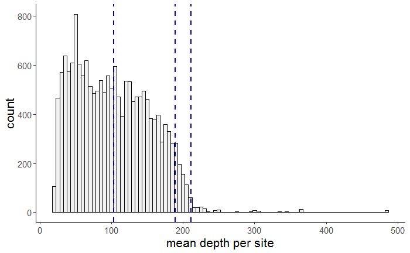

```r
# import mean depth per site
meandepthpersite <- read.table("data/VCF/FamB.meandepthpersite", header = FALSE)
# look at distribution
ggplot(meandepthpersite, aes(x = V1)) +
  geom_histogram(binwidth = 5, color = "black", fill = "grey95") +
  geom_vline(aes(xintercept = mean(V1, na.rm = TRUE)),
                 color = "darkblue", linetype = "dashed", size = 1) +
  geom_vline(aes(xintercept = quantile(meandepthpersite$V1, .95)),
                 color = "darkblue", linetype = "dashed", size = 1) +
  geom_vline(aes(xintercept = quantile(meandepthpersite$V1, .99)),
                 color = "darkblue", linetype = "dashed", size = 1) +
  labs(x = "mean depth per site") +
  theme_standard
```

Choose cut-off value = 200. Combine both depth filters to produce filtered data set.

```
vcftools --vcf  FamB.F10.vcf --max-meanDP 200 --exclude-positions FamB.F10.lowQDloci --recode --recode-INFO-all --out FamB.F11
```

Remaining number of loci: 16,638.

```
mawk '!/#/' FamB.F11.recode.vcf | wc -l
```

#### Filter 12: Remove Indels

Remove Indels from data set.

```
vcfallelicprimitives FamB.F11.recode.vcf --keep-info --keep-geno > FamB.prim.vcf
vcftools --vcf FamB.prim.vcf --out FamB.F12 --remove-indels --recode --recode-INFO-all
```

Remaining number of loci: 16,805.

```
mawk '!/#/' FamB.F12.recode.vcf | wc -l
```

#### Filter 13: Minor allele frequency

Set final cut-off for minor allele frequncy at 0.05

```
vcftools --vcf FamB.F12.recode.vcf --out FamB.F13 --maf 0.05 --recode --recode-INFO-all
```

Loci remaining: 16,802.

```
vcftools --vcf FamB.F13.recode.vcf --out FamB.F13 --het
vcftools --vcf FamB.F13.recode.vcf --out FamB.F13 --missing-indv
vcftools --vcf FamB.F13.recode.vcf --out FamB.F13 --missing-site
vcftools --vcf FamB.F13.recode.vcf --out FamB.F13 --depth
vcftools --vcf FamB.F13.recode.vcf --out FamB.F13 --site-mean-depth
```

**Assess individual quality**

Identify low quality individuals by comparing levels of missing data and read depth.

```r
ind_stats_F13 <- read.ind.stats(dir = "data/VCF", vcf = "FamB.F13") %>%
  separate(INDV, into = c("SP", "LIB", "SAMPLE_ID"), sep = "_", remove = FALSE)
```

Mean read depth per individual across all SNP sites, the mean mean depth across all SNP sites is 102.3138084, the 5th % quantile is 31.22827:

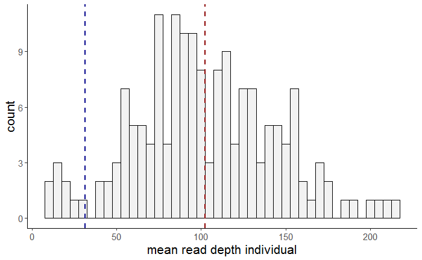

```r
ggplot(ind_stats_F13, aes(x = MEAN_DEPTH_FamB.F13)) +
  geom_histogram(binwidth = 5, color = "black", fill = "grey95") +
  geom_vline(aes(xintercept = mean(MEAN_DEPTH_FamB.F13, na.rm = TRUE)),
                 color = "darkred", linetype = "dashed", size = 1) +
  geom_vline(aes(xintercept = quantile(MEAN_DEPTH_FamB.F13, .05)),
                 color = "darkblue", linetype = "dashed", size = 1) +
  labs(x = "mean read depth individual") +
  theme_standard
```

Frequency of missing data per individual across all SNP sites; the mean mean depth across all individuals is 0.0051548, the 95th % quantile is 0.0166052:

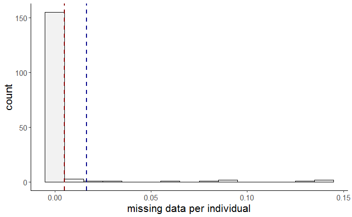

```r
ggplot(ind_stats_F13, aes(x = MISS_FamB.F13)) +
  geom_histogram(binwidth = .01, color = "black", fill = "grey95") +
  geom_vline(aes(xintercept = mean(MISS_FamB.F13, na.rm = TRUE)),
                 color = "darkred", linetype = "dashed", size = 1) +
  geom_vline(aes(xintercept = quantile(MISS_FamB.F13, .95)),
                 color = "darkblue", linetype = "dashed", size = 1) +
  labs(x = "missing data per individual") +
  theme_standard
```

Heterozygosity per individual across all SNP sites; the mean values for Fis is -0.2229474, the 95th % quantile is -0.145266 and the 5th % quantile is -0.461034:

```
There were 16 warnings (use warnings() to see them)
```

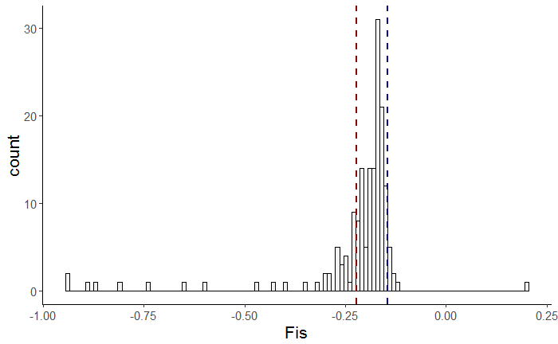

```r
ggplot(ind_stats_F13, aes(x = Fis_FamB.F13)) +
  geom_histogram(binwidth = .01, color = "black", fill = "grey95") +
  geom_vline(aes(xintercept = mean(Fis_FamB.F13, na.rm = TRUE)),
                 color = "darkred", linetype = "dashed", size = 1) +
  geom_vline(aes(xintercept = quantile(Fis_FamB.F13, .95)),
                 color = "darkblue", linetype = "dashed", size = 1) +
  labs(x = "Fis") +
  theme_standard
```

#### Filter 15: Missing data

Set final cut-off for genotype call rate to > 95%.

```
vcftools --vcf FamB.F13.recode.vcf --out FamB.F15a --max-missing 0.95 --recode --recode-INFO-all
vcftools --vcf FamB.F15a.recode.vcf --out FamB.F15a --missing-indv
```

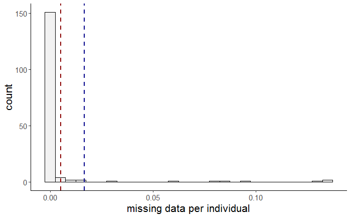

```r
imiss_F15 <- read.table("data/VCF/FamB.F15a.imiss",
                       header = TRUE, stringsAsFactors = FALSE, quote = NULL)
ggplot(imiss_F15, aes(x = F_MISS)) +
  geom_histogram(binwidth = .005, color = "black", fill = "grey95") +
  geom_vline(aes(xintercept = mean(F_MISS, na.rm = TRUE)),
                 color = "darkred", linetype = "dashed", size = 1) +
  geom_vline(aes(xintercept = quantile(F_MISS, .95)),
                 color = "darkblue", linetype = "dashed", size = 1) +
  labs(x = "missing data per individual") +
  theme_standard
```

Set final cut-off for allowable missing data per individual to < 25%.

```
mawk -v x=0.25 '$5 > x' FamB.F15a.imiss | cut -f1 > lowDP.indv
vcftools --vcf FamB.F15a.recode.vcf --out FamB.SNP --remove lowDP.indv --recode --recode-INFO-all
```

Final data set consisnts of 16,802 loci and 167 individuals.

```
vcftools --vcf FamB.SNP.recode.vcf --out FamB.SNP --missing-indv
vcftools --vcf FamB.SNP.recode.vcf --out FamB.SNP --missing-site
vcftools --vcf FamB.SNP.recode.vcf --out FamB.SNP --site-mean-depth
vcftools --vcf FamB.SNP.recode.vcf --out FamB.SNP --depth
vcftools --vcf FamB.SNP.recode.vcf --out FamB.SNP --het
vcftools --vcf FamB.SNP.recode.vcf --out FamB.SNP --hardy
vcftools --vcf FamB.SNP.recode.vcf --out FamB.SNP --freq
```

### Final thresholds values for filtered data set FamB:

- minimum sequence quality (minQ): 20
- minimum genotype call rate per locus (geno): 95%
- minimum minor allele count (mac): 3
- minimum depth (minD): 5
- maximum missing data per individual (missInd): 25%
- minimum minor allele frequence (maf): 0.05
- mean minimum depth (m-minD): 20
- dDocent filters run for allelic balance, Forward/Reverse and paired status, depth/quality ratio and maximum mean depth
- Indels removed from data set

The final data set contains 16,802 loci and 167 individuals.

# Haplotyping

## Create haplotypes FamA

Create list of individuals retained in final vcf file:

```
vcftools --vcf FamA.SNP.recode.vcf --out FamA --recode --recode-INFO-all
vcfsamplenames FamA.recode.vcf > FamA.individuals
```

Parental genotypes: * Father: SFL-A-M1 * Mother: SFL-A-F1

Use `SFL-FamA.individuals` to create `popmap` as a tab-separated file of individuals and their population designation, with one individual per line (make sure UNIX format). This file is needed to write the genepop file, if not provided the script will run through the process but not write a genepop file and place into same folder `rad_haplotyper.pl` will be run from.

```
nohup rad_haplotyper.pl -v FamA.recode.vcf -r reference.fasta -x 35 -d 10 -z 3 -m .5 -g FamA.gen -p FamB.popmap -t FamA.tsv -p1 SFL-1_SFL-A-F1 -p2 SFL-1_SFL-A-M1 -e
```

Copy files for analysis into `data/VCF/`-folder: * FamA_ind_stats.out * FamA_stats.out * FamA.gen * FamA.tsv

## Create haplotypes FamB

Parental genotypes: * Father: FamB-194 * Mother: FamB-059

Remove Male 2 (193) from vcf-file:

```
vcftools --vcf FamB.SNP.recode.vcf --out FamB --recode --recode-INFO-all --remove-indv FamB_FamB-193
```

Create list of individuals retained in final vcf file:

```
vcfsamplenames FamB.recode.vcf > FamB.individuals
```

Use `FamB.individuals` to create `FamB.popmap` as a tab-separated file of individuals and their population designation, with one individual per line (make sure UNIX format). This file is needed to write the genepop file, if not provided the script will run through the process but not write a genepop file and place into same folder `rad_haplotyper.pl` will be run from.

```
nohup rad_haplotyper.pl -v FamB.recode.vcf -r reference.fasta -x 55 -d 10 -z 3 -m .5 -g FamB.gen -p FamB.popmap -t FamB.tsv -p1 FamB_FamB-059 -p2 FamB_FamB-194 -e
```

Rename files and copy for analysis into `data/VCF/`-folder: * FamB_ind_stats.out * FamB_stats.out * FamB.gen * FamB.tsv

# Filter Haplotypes FamA

## Overview of haplotyping success

Create list of loci to filter from linkage map file (`*.tsv`-file), this can be done before converting to `*.raw` for analysis in r/QTL and onemap as the file format is one locus per row, then the genotype call in each individual.

| Count > 163 | n |
| --- | --- |
| FALSE | 570 |
| TRUE | 3764 |

```r
# import genepop file
# import tsv file
FamA_tsv <- read.delim("data/VCF/FamA.tsv", header = TRUE)
count(FamA_tsv, Count > 163)

# remove all loci not called in at least 80% of individuals
FamA_tsv <- FamA_tsv %>%
    filter(Count > 163)
```

Remove loci not called in 90% of offspring (163 individuals) from `*.tsv`-file.

## Summary stats by locus

Comparison of the number of loci that were filtered due to excess number of missing data or suspected paralogs during the haplotyping process to those that passed. Haplotyer was run without any threshold values (other than default values). The genepop file only contains loci that passed haplotyping stage.

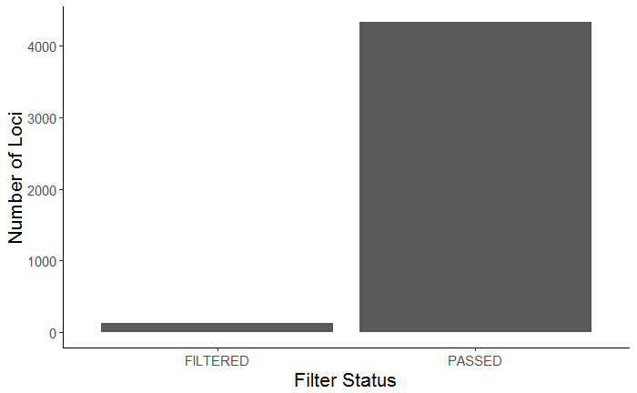

Overview of haplotyping stats per locus:

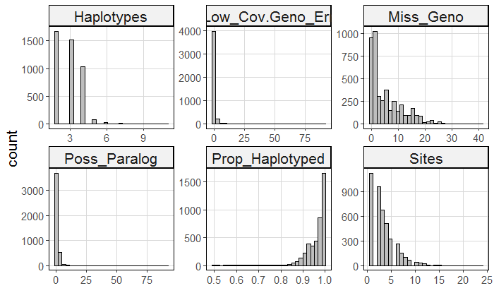

Overview of haplotyping stats per individual:

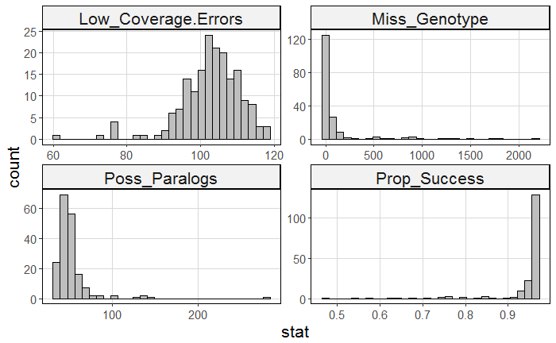

## Identify threshold values to filter data set

### Proportion of individuals haplotyped

| Prop_Haplotyped > 0.95 | n |
| --- | --- |
| FALSE | 1256 |
| TRUE | 3078 |

### Possible paralogs per locus

Loci are flagged as possible paralogs for an individuals when more than the expected number of haplotypes based on the genotype call (homozygote, heterozygote) are detected.

```r
quantile(hap_statsA$Poss_Paralog, c(.5, .75, .85, .9, .95, 0.99))
```

```
50% 75% 85% 90% 95% 99%
  0   1   2   2   3  30
```

### Number of SNPs & Haplotypes per locus

Each locus varies in the number of SNPs detected which determines the number of haplotypes expected in that population. Loci can be excluded from the final data set by looking at the distribution of values to determine loci with an excessive amount of SNPs which could potentially be sequencing error or something similar.

| Sites > 5 | n |
| --- | --- |
| FALSE | 3620 |
| TRUE | 714 |

### Low Coverage/Genotyping Error

After combining SNPs at the same contig during the haplotyping process it is possible to observe fewer than the expected number of haplotypes. When this occurs, that is coded as missing data for that particular indvidual and the locus is flagged as a potential genotyping error or suffering from allelic drop out and the number of individuals with potential genotyping error/allelic dropout due to low coverage detected for a given locus is recorded. Cut-off value to remove locus if flagged as potential genotyping error in more than 1% of individuals is 1.83.

| Low_Cov.Geno_Err > 2 | n |
| --- | --- |
| FALSE | 4092 |
| TRUE | 242 |

### Identify problematic individuals

**Possible paralogs per individual**

| Poss_Paralogs > 433 | n |
| --- | --- |
| FALSE | 183 |

The highest number of flagged loci in an individuals is 277, which is equivalent to 6.39% of loci.

**Individuals with low proportion of successfully haplotyped loci**

Problem individuals can be identified by choosing a cut-off value for the minium proportion of sucessfully haplotyped loci and excluding individuals below that threshold value.

| Prop_Success < 0.9 | n |
| --- | --- |
| FALSE | 164 |
| TRUE | 19 |

**Individuals with high proportion of potential allele dropout/genotyping error**

Remove individuals with high proportion of loci that have been flagged as potential allele dropouts/genotyping error.

| Low_Coverage.Errors > 433 | n |
| --- | --- |
| FALSE | 183 |

The highest number of flagged loci in an individuals is 117, which is equivalent to 2.7% of loci.

## Remove loci from tsv file

```r
FamA_tsv_filtered <- FamA_tsv %>%
    filter(!Locus %in% NoSNps) %>%
    filter(!Locus %in% Geno_Err) %>%
    filter(!Locus %in% NoHaps) %>%
    filter(!Locus %in% Poss_Paralogs) %>%
    filter(!Locus %in% Prop_Haplotyped) %>%
    filter(!Parents == "aa/aa") %>%
    filter(!Parents == "--/--") %>%
    select(-`SFL.1_SFL.A.022`) %>%
    select(-`SFL-1_SFL-A-037`) %>%
    select(-`SFL-1_SFL-A-038`) %>%
    select(-`SFL-1_SFL-A-046`) %>%
    select(-`SFL-1_SFL-A-086`) %>%
    select(-`SFL-1_SFL-A-087`) %>%
    select(-`SFL-1_SFL-A-088`) %>%
    select(-`SFL-1_SFL-A-092`) %>%
    select(-`SFL-1_SFL-A-095`) %>%
    select(-`SFL-1_SFL-A-115`) %>%
    select(-`SFL-1_SFL-A-116`) %>%
    select(-`SFL-1_SFL-A-125`) %>%
    select(-`SFL-1_SFL-A-129`) %>%
    select(-`SFL-1_SFL-A-154`) %>%
    select(-`SFL-1_SFL-A-178`) %>%
    select(-`SFL-1_SFL-A-188`) %>%
    select(-`SFL-1_SFL-A-200`) %>%
    select(-`SFL-1_SFL-A-205`) %>%
    select(-`SFL-1_SFL-A-211`)
```

[output not shown]

# Filter haplotypes FamB

## Overview of haplotyping success

Create list of loci to filter from linkage map file (`*.tsv`-file), this can be done before converting to `*.raw` for analysis in r/QTL and onemap as the file format is one locus per row, then the genotype call in each individual.

| Count > 149 | n |
| --- | --- |
| FALSE | 529 |
| TRUE | 3692 |

```r
FamB_tsv <- read.delim("data/VCF/FamB.tsv", header = TRUE)
count(FamB_tsv, Count > 149)

# remove all loci not called in at least 90% of individuals
FamB_tsv <- FamB_tsv %>%
  filter(Count > 157)
```

## Summary stats by locus

Comparison of the number of loci that were filtered due to excess number of missing data or suspected paralogs during the haplotyping process to those that passed. Haplotyer was run without any threshold values (other than default values). The genepop file only contains loci that passed haplotyping stage.

```r
hap_statsB <- remove.filtered.haps(hap_statsB)
```

[output not shown]

Overview of haplotyping stats per locus:

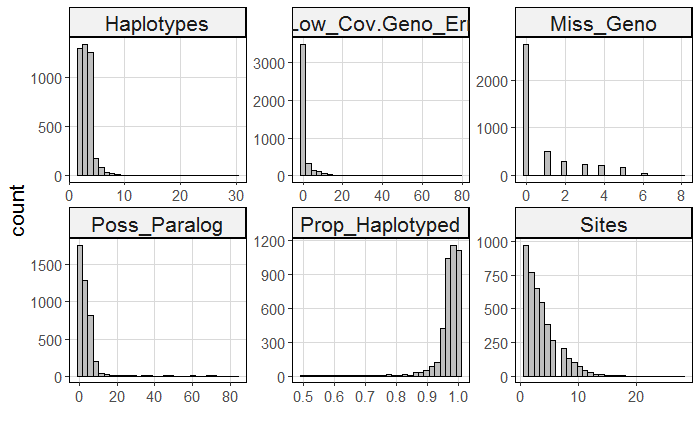

Overview of haplotyping stats per individual:

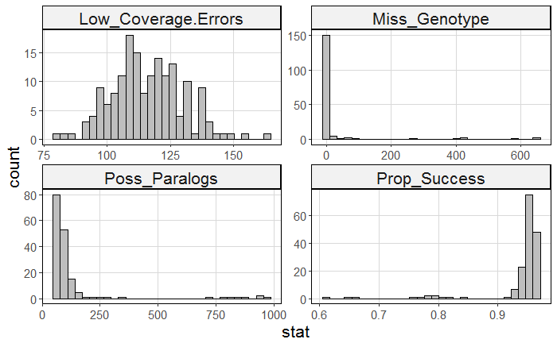

## Identify threshold values to filter data set

### Proportion of individuals haplotyped

| Prop_Haplotyped < 0.95 | n |
| --- | --- |
| FALSE | 3480 |
| TRUE | 741 |

### Possible paralogs per locus

Loci are flagged as possible paralogs for an individuals when more than the expected number of haplotypes based on the genotype call (homozygote, heterozygote) are detected.

Base threshold values on percent of individuals a locus was flagged as a potential paralog or based on distribution. 5% of individuals would mean that a locus was flagged in 8.3 individuals.

| Poss_Paralog > 8 | n |
| --- | --- |
| FALSE | 3964 |
| TRUE | 257 |

### Number of SNPs per locus

Each locus varies in the number of SNPs detected which determines the number of haplotypes expected in that population. Loci can be excluded from the final data set by looking at the distribution of values to determine loci with an excessive amount of SNPs which could potentially be sequencing error or something similar.

| Sites > 5 | n |
| --- | --- |
| FALSE | 3324 |
| TRUE | 897 |

```r
count(hap_statsB, Sites > 5)

count(hap_statsB, Haplotypes > 4)
```

| Haplotypes > 4 | n |
| --- | --- |
| FALSE | 3879 |
| TRUE | 342 |

### Low Coverage/Genotyping Error

| Low_Cov.Geno_Err > 1 | n |
| --- | --- |
| FALSE | 3490 |
| TRUE | 731 |

Filter loci flagged as potential genotyping error in more than 1% of individuals (731 loci).

### Identify problematic individuals

**Possible paralogs per individual**

| Poss_Paralogs > 422 | n |
| --- | --- |
| FALSE | 158 |
| TRUE | 8 |

**Individuals with low proportion of successfully haplotyped loci**

Problem individuals can be identified by choosing a cut-off value for the minium proportion of sucessfully haplotyped loci and excluding individuals below that threshold value.

| Prop_Success < 0.8 | n |
| --- | --- |
| FALSE | 157 |
| TRUE | 9 |

**Individuals with high proportion of potential allele dropout/genotyping error**

Remove individuals with high proportion of loci that have been flagged as potential allele dropouts/genotyping error.

| Low_Coverage.Errors > 433 | n |
| --- | --- |
| FALSE | 166 |

## Remove loci and individuals from tsv file

Filtered data set contains 2352 loci and 151 individuals.

# Prepare final data set for mapping

Convert `*filtered.tsv`-file using `map_convert.pl`. Make sure that UNIX text file format before executing script.

## Family A

Create male and female map (mapmaker format) for analysis in `r/qtl`:

```
# male map
perl map_convert.pl -i FamA.filtered.tsv -n tsv -o FamA-M -u mm -s M -F SFL-A-F1 -M SFL-A-M1 -l 0.9 -c 0.9

# female map
perl map_convert.pl -i FamA.filtered.tsv -n tsv -o FamA-F -u mm -s F -F SFL-A-F1 -M SFL-A-M1 -l 0.9 -c 0.9
```

Rename and move outputfiles in `data/LINKMAP`:

- FamA-F.raw (individuals in file `FamA-F.ind`)
- FamA-M.raw (individuals in file `FamA-M.ind`)

Create onemap input file:

```
perl map_convert.pl -i FamA.filtered.tsv -n tsv -o FamA -u onemap -F SFL-A-F1 -M SFL-A-M1 -l 0.9 -c 0.9
```

Rename and move output files to `data/LINKMAP`:

- FamA.onemap (individuals in file `FamA.onemap.inds`)

## Family B

Create sex-specific input files for filtering in r/QTL:

```
# male map
perl map_convert.pl -i FamB.filtered.tsv -n tsv -o FamB-M -u mm -s M -F SFL-FamB.059 -M SFL-FamB.194 -l 0.9 -c 0.9

# female map
perl map_convert.pl -i FamB.filtered.tsv -n tsv -o FamB-F -u mm -s F -F SFL-FamB.059 -M SFL-FamB.194 -l 0.9 -c 0.9
```

Rename and move outputfiles in `data/LINKMAP`:

- FamB-F.raw (individuals in file `FamB-F.ind`)
- FamB-M.raw (individuals in file `FamB-M.ind`)

Create onemap input file:

```
perl map_convert.pl -i FamB.filtered.tsv -n tsv -o FamB -u onemap -F SFL-FamB.059 -M SFL-FamB.194 -l 0.9 -c 0.9
```

Rename and move output files to `data/LINKMAP`:

- FamB.onemap (individuals in file `FamB.onemap.inds`)